# Graficación y Tidyverse

Estudiante: Francini Acuña Piedra

Curso: TPB728O Programación de aplicaciones geoespaciales en R 2021-II

Contenido:

2.Histograma que muestre la distribución de los casos nuevos de covid en Costa Rica. Elija cuidadosamente el tamaño de los “bins”.

3.Gráfico de barras agrupadas que muestre la cantidad de hombres y mujeres fallecidos por covid en Costa Rica por cada uno de los 12 meses del año.

## Preparativos de datos

```r
#Carga de libreria
# dplyr
library (dplyr)
```

```r
# ggplot2
library(ggplot2)
```

```r
# Carga de hrbrthemes
library(hrbrthemes)
```

#Carda de datoS

```r
# Ríos
# Carga de datos desde un archivo CSV
rios <-
  read.csv(file = 'https://raw.githubusercontent.com/tpb728O-programaciongeoespacialr/2021ii/main/datos/hidrologia/fdc/fdc.csv')

#Covid
# Carga de datos desde un archivo CSV
covid <-
  read.csv(
    file='https://raw.githubusercontent.com/tpb728O-programaciongeoespacialr/2021ii/main/datos/minsalud/covid/ultimafecha_CSV_GENERAL.csv',
    sep = ","
  )
```

## dply

### mutate

```r
str(rios)
```

```
## 'data.frame':    3845 obs. of  3 variables:
##  $ Tiempo             : chr  "6/22/1973" "6/23/1973" "6/24/1973" "6/25/1973" ...
##  $ Pandora.mm..637km2.: num  7.46 6.17 6.32 7.8 7.72 7.83 5.02 3.84 3.21 2.77 ...
##  $ Banano.mm..90km2.  : num  21 14.8 27.6 19.7 15.2 ...
```

```r
# Cambio de nombre de las columnas mediante rename()
rios <-
  rios %>%
  rename(fecha = Tiempo,
         pandora = Pandora.mm..637km2.,
         banano = Banano.mm..90km2.)
```

```r
# Conversión de una columna a tipo Date y creación de una nueva columna
rios <-
  rios %>%
  mutate(fecha = as.Date(fecha, format = "%m/%d/%Y"),
         promedio = (pandora + banano) / 2)
```

```r
# Selección, renombramiento y conversión de columnas
covid_columnas_seleccionadas <-
  covid %>%
  select(FECHA, muj_posi, hom_posi) %>%
  rename(
    fecha = FECHA,
    positivos_mujeres = muj_posi,
    positivos_hombres = hom_posi
  ) %>%
  mutate(fecha = as.Date(fecha, format = "%d/%m/%Y"))
```

```r
# Selección, renombramiento, conversión de columnas y filtrado
covid_filtrado <-
  covid %>%
  select(FECHA, nue_posi) %>%
  rename(fecha = FECHA, positivos_nuevos = nue_posi) %>%
  mutate(fecha = as.Date(fecha, format = "%d/%m/%Y")) %>%
  filter(positivos_nuevos >= 2500)

# Despliegue del data frame con los resultados
covid_filtrado
```

```
##         fecha positivos_nuevos
## 1  2021-04-29             2781
## 2  2021-04-30             2609
## 3  2021-05-05             2555
## 4  2021-05-06             2559
## 5  2021-05-12             3173
## 6  2021-05-13             3039
## 7  2021-05-14             2815
## 8  2021-05-15             2795
## 9  2021-05-19             2900
## 10 2021-05-20             2812
## 11 2021-05-21             2587
## 12 2021-05-26             2587
## 13 2021-08-25             2619
## 14 2021-08-26             2706
## 15 2021-08-27             2787
## 16 2021-08-31             2581
## 17 2021-09-01             2848
## 18 2021-09-02             2991
## 19 2021-09-03             2750
## 20 2021-09-07             2956
## 21 2021-09-08             2884
## 22 2021-09-09             2975
## 23 2021-09-10             2825
## 24 2021-09-11             2546
```

#Graficación

```r
#Sumar caudal  mes
# Selección, renombramiento, filtrado y conversión de columnas
sumarizado_x_mes <-
  rios %>%
  select(fecha, pandora, banano) %>%
  rename(fecha = fecha, caudal_pandora = pandora, caudal_banano = banano) %>%
  mutate(fecha = as.Date(fecha, format = "%d/%m/%Y")) %>%
  group_by( mes = format(fecha,"%m")) %>%
  summarise(suma_caudal_pandora = sum(caudal_pandora ), suma_caudal_banano = sum(caudal_banano))

# Despliegue del data frame con los resultados
sumarizado_x_mes
```

```
## # A tibble: 12 x 3
##    mes   suma_caudal_pandora suma_caudal_banano
##    <chr>               <dbl>              <dbl>
##  1 01                  1523.              4265.
##  2 02                  1240.              3655.
##  3 03                  1243.              2699.
##  4 04                  1275.              3163.
##  5 05                  1392.              4646.
##  6 06                  1898.              5302.
##  7 07                  2484.              6013.
##  8 08                  2441.              4768.
##  9 09                  1567.              4016.
## 10 10                  1710.              4211.
## 11 11                  1776.              5877.
## 12 12                  2442.              6284.
```

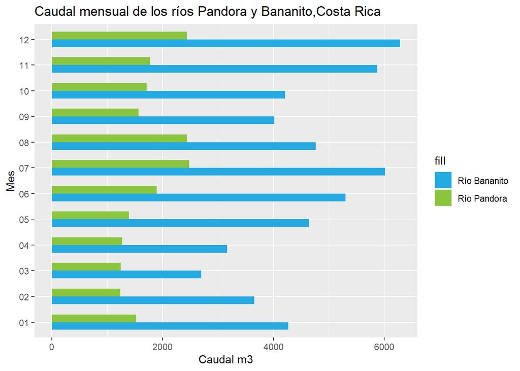

```r
# Grafico de barras agrupadas
ggplot() +
  geom_col(
  data = sumarizado_x_mes ,
  aes(x = mes, y = suma_caudal_banano, fill = "Río Bananito"),
  width = 0.3,
  position = position_nudge(x = -0.15)
  ) +

  geom_col(
    data = sumarizado_x_mes ,
    aes(x = mes, y = suma_caudal_pandora, fill = "Río Pandora"),
    width = 0.3,
    position = position_nudge(x = 0.15)
    ) +
  coord_flip()+
  scale_fill_manual(values = c("#25AAE2","#8BC540")) +
  ggtitle( "Caudal mensual de los ríos Pandora y Bananito,Costa Rica") +
  xlab("Mes") +
  ylab("Caudal m3") +
  theme(

    )
```

#2.Histograma que muestre la distribución de los casos nuevos de covid en Costa Rica. Elija cuidadosamente el tamaño de los “bins”

```r
# Promedio de casos nuevos por mes
covid_positivos_nuevos_promedio_x_mes <-
  covid %>%
  select(FECHA, nue_posi) %>%
  rename(fecha = FECHA, positivos_nuevos = nue_posi) %>%
  mutate(fecha = as.Date(fecha, format = "%d/%m/%Y")) %>%
  group_by(mes = format(fecha,"%m")) %>%
  summarise(suma_positivos = mean(positivos_nuevos))
covid_positivos_nuevos_promedio_x_mes
```

```
## # A tibble: 12 x 2
##    mes   suma_positivos
##    <chr>          <dbl>
##  1 01              805.
##  2 02              380.
##  3 03              224.
##  4 04              567.
##  5 05             1102.
##  6 06              856.
##  7 07              881.
##  8 08             1274.
##  9 09             1534.
## 10 10             1104.
## 11 11              989.
## 12 12              958.
```

```r
covid_ <-
  covid %>%
  select(FECHA, nue_posi) %>%
  rename(fecha = FECHA, positivos_nuevos = nue_posi) %>%
  mutate(fecha = as.Date(fecha, format = "%d/%m/%Y"))
```

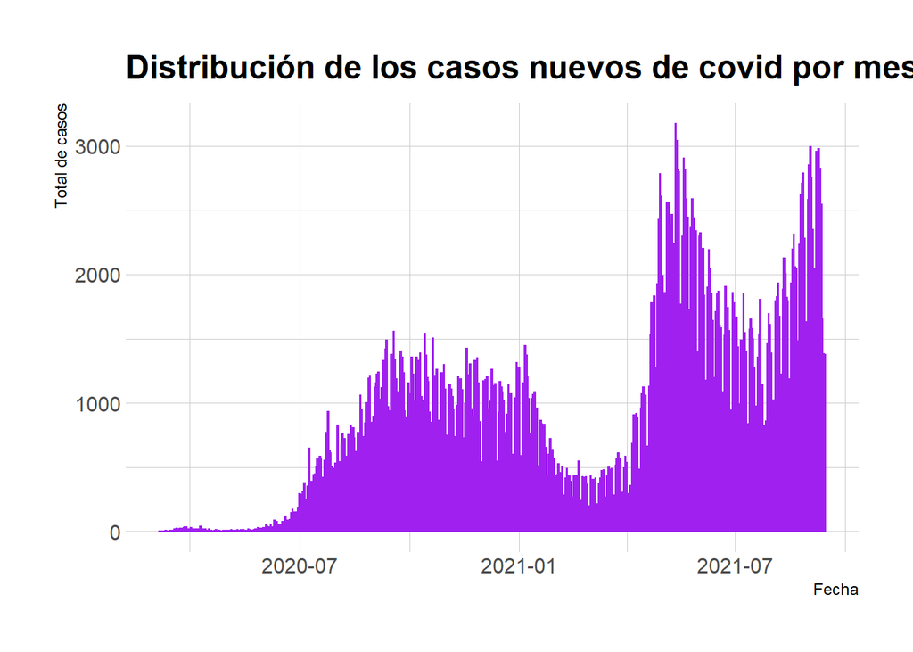

```r
# Histograma Casos nuevos de COVID-19
ggplot(covid_, aes(x = fecha, y = positivos_nuevos)) +
  geom_histogram(binwidth = 0.20, stat= 'identity', color= "purple" ) +
  ggtitle("Distribución de los casos nuevos de covid por mes en Costa Rica") +
  xlab("Fecha")+
  ylab("Total de casos")+
  theme_ipsum()
```

#3.Gráfico de barras agrupadas que muestre la cantidad de hombres y mujeres fallecidos por covid en Costa Rica por cada uno de los 12 meses del año.

```r
#Sumar personas fallecidas por sexo por mes
# Selección, renombramiento, filtrado y conversión de columnas
sumarizado_fallecidos_sexo_mes <-
  covid %>%
  select(FECHA, hom_fall, muj_fall) %>%
  rename(FECHA = FECHA, mujeres_fallecidas = muj_fall, hombres_fallecidos = hom_fall) %>%
  mutate(FECHA = as.Date(FECHA, format = "%d/%m/%Y")) %>%
  group_by( mes = format(FECHA,"%m")) %>%
  summarise(suma_muj_fall = sum(mujeres_fallecidas ), suma_hom_fall = sum(hombres_fallecidos))

# Despliegue del data frame con los resultados
sumarizado_fallecidos_sexo_mes
```

```
## # A tibble: 12 x 3
##    mes   suma_muj_fall suma_hom_fall
##    <chr>         <int>         <int>
##  1 01            28265         46826
##  2 02            28663         47764
##  3 03            33380         56004
##  4 04            34671         57765
##  5 05            42664         69826
##  6 06            50512         81968
##  7 07            58447         94056
##  8 08            66182        106142
##  9 09            38315         60911
## 10 10            13629         22337
## 11 11            17780         29062
## 12 12            22933         37934
```

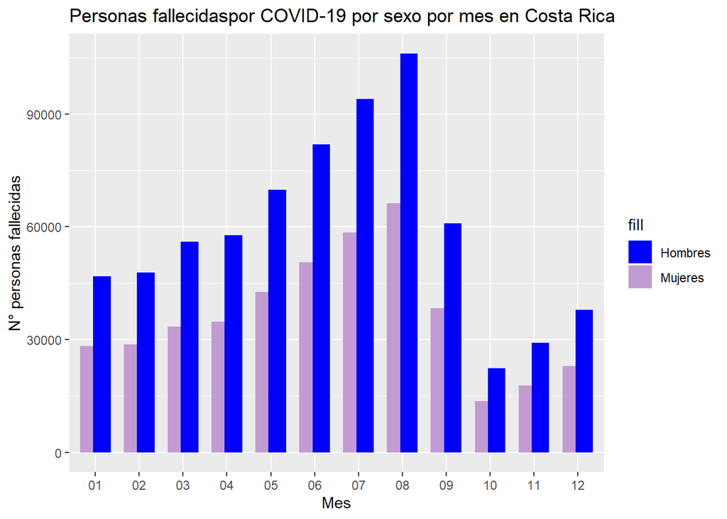

```r
# Grafico de barras agrupadas
ggplot() +
  geom_col(
  data = sumarizado_fallecidos_sexo_mes ,
  aes(x = mes, y = suma_muj_fall, fill = "Mujeres"),
  width = 0.4,
  position = position_nudge(x = -0.15)
  ) +

  geom_col(
    data = sumarizado_fallecidos_sexo_mes ,
    aes(x = mes, y = suma_hom_fall, fill = "Hombres"),
    width = 0.4,
    position = position_nudge(x = 0.15)
    ) +
  scale_fill_manual(values = c("#0000FF", "#c39bd3")) +
  ggtitle( "Personas fallecidaspor COVID-19 por sexo por mes en Costa Rica") +
  xlab("Mes") +
  ylab("N° personas fallecidas") +
  theme(

    )
```